# Zambia Analysis

Branden Bohrnsen

2024-06-29

```r
ddi <- read_ipums_ddi("ipumsi_00001.xml")
data <- read_ipums_micro(ddi)
```

```
## Use of data from IPUMS International is subject to conditions including that users should cite the data appropriately. Use command `ipums_conditions()` for more details.
```

Poly households are not fully captured by `HHTYPE`

```r
table(data_2010$HHTYPE, data_2010$POLYMAL)
```

```
##
##                                                 More than one wife linked via SPLOC
##   Composite household, family and non-relatives                                  85
##   Extended family, relatives only                                              2631
##   Married/cohab couple with children                                              0
##   Married/cohab couple, no children                                               0
##   Non-family household                                                            0
##   One-person household                                                            0
##   Polygamous family                                                            1339
##   Single-parent family                                                            0
##   Unclassifiable                                                                  8
##
##                                                 No more than one wife linked via SPLOC
##   Composite household, family and non-relatives                                  27599
##   Extended family, relatives only                                               622336
##   Married/cohab couple with children                                            529355
##   Married/cohab couple, no children                                              20518
##   Non-family household                                                            4896
##   One-person household                                                           15483
##   Polygamous family                                                               9145
##   Single-parent family                                                           80586
##   Unclassifiable                                                                  7992
```

So we capture them using `POLYMAL`

```r
poly <- data_2010 %>% group_by(SERIAL) %>%
  mutate(POLY = any(POLYMAL == "More than one wife linked via SPLOC"))

table(poly$POLY)
```

```
##
##   FALSE    TRUE
## 1280762   41211
```

```r
poly <- poly %>%
  filter(POLY == TRUE)
```

Ignore poly groups for now, not sure how we should implement these. Flag if more than one ethnicity is present in the relationship?

```r
married <- data_2010 %>% group_by(SERIAL) %>%
  mutate(POLY = any(POLYMAL == "More than one wife linked via SPLOC")) %>%
  filter(POLY == FALSE)

cat("Ratio of poly to married count:", nrow(poly)/nrow(married))
```

```
## Ratio of poly to married count: 0.03217694
```

```r
married <- married %>%
  filter(MARST == "Married/in union") %>%
  mutate(SPLOC = case_when(
    as.factor(SPLOC) == 0 ~ "Spouse not in household",
    .default = as.factor(SPLOC)
  )
)

# the vast majority have no spouse
#view(as.data.frame(table(data_2010$SPLOC)))

view(as.data.frame(table(data_2010$MARST, data_2010$SPLOC)))

concerning <- as.data.frame(table(married$SERIAL, married$RELATE, married$NFAMS))
concerning <- pivot_wider(concerning, names_from = "Var2", values_from = "Freq")
```

Handling some unusual cases – the `RELATE` variable has some entry errors it seems

*NOTE: I manually looked through these households – they are all women and many young men. Only one man has the `SPLOC`* *filled out, but all other marriage variables indicate marriage. I suspect they calculated age of first marriage using the `RELATE`* *variable, creating a chain of error, but could be wrong. I’ll keep them in the data for now*

```
## # A tibble: 6 × 7
##   Var1      Var3    Child  Head `Non-relative` `Other relative` `Spouse/partner`
##   <fct>     <fct>   <int> <int>          <int>            <int>            <int>
## 1 895000    1 fami…     0     1              0                1               11
## 2 123602000 1 fami…     0     1              0                0                7
## 3 137254000 1 fami…     0     1              0                1                7
## 4 336000    1 fami…     0     1              0                0                6
## 5 2414000   1 fami…     0     1              0                0                6
## 6 102159000 1 fami…     0     1              0                0                6
```

Join the married couples together

*NOTE: All M-M pairings were removed, presumably in the erasure of poly groupings*

```r
married_joined <- married %>% filter(SEX == "Male") %>%
  inner_join(married %>% mutate(PERNUM = as.character(PERNUM)),
             by = c("SERIAL" = "SERIAL", "SPLOC" = "PERNUM"),
             suffix = c("_M", "_F")
             )
all(married_joined$PERNUM == married_joined$SPLOC_F) # Ensuring everyone is correctly paired
```

```
## [1] TRUE
```

```r
all(married_joined$SEX_F != married_joined$SEX_M) # Verify opposite-sex
```

```
## [1] TRUE
```

See how many households have more than one pairing

```
## Ratio of households with more than one pairing to all households: 0.01075269
```

Add the variables of interest

```r
married_joined <- married_joined %>% mutate(
  INTERMAR = case_when(
    ETHNICZM_M != ETHNICZM_F ~ "Yes",
    ETHNICZM_M == ETHNICZM_F ~ "No",
    .default = "Something went wrong"),
  YRMAR = 2010 - (as.numeric(AGE_F) - as.numeric(AGEMARR_F)),
  URBAN = ifelse(POPDENSGEO2_M > 20, "URBAN", "RURAL"),
  FULL_RESIDE = (as.numeric(AGE_F) - as.numeric(AGEMARR_F)) <= MIGYRS1_F)

table(married_joined$INTERMAR)
```

```
##
##     No    Yes
## 101433  55545
```

Distribution of `AGEMARR`

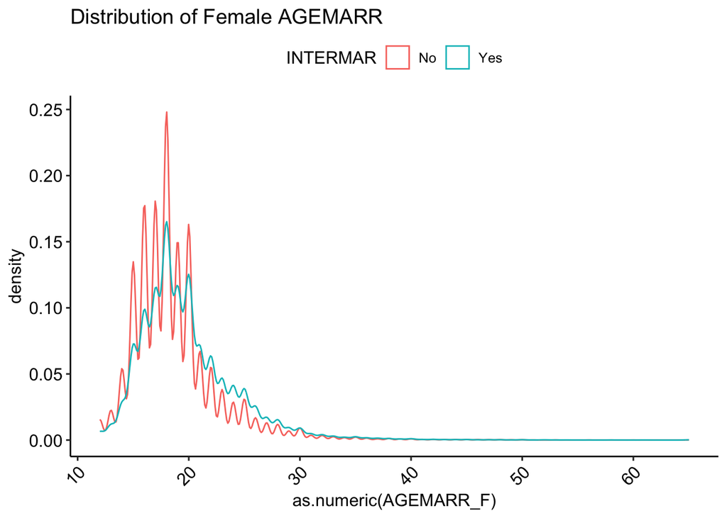

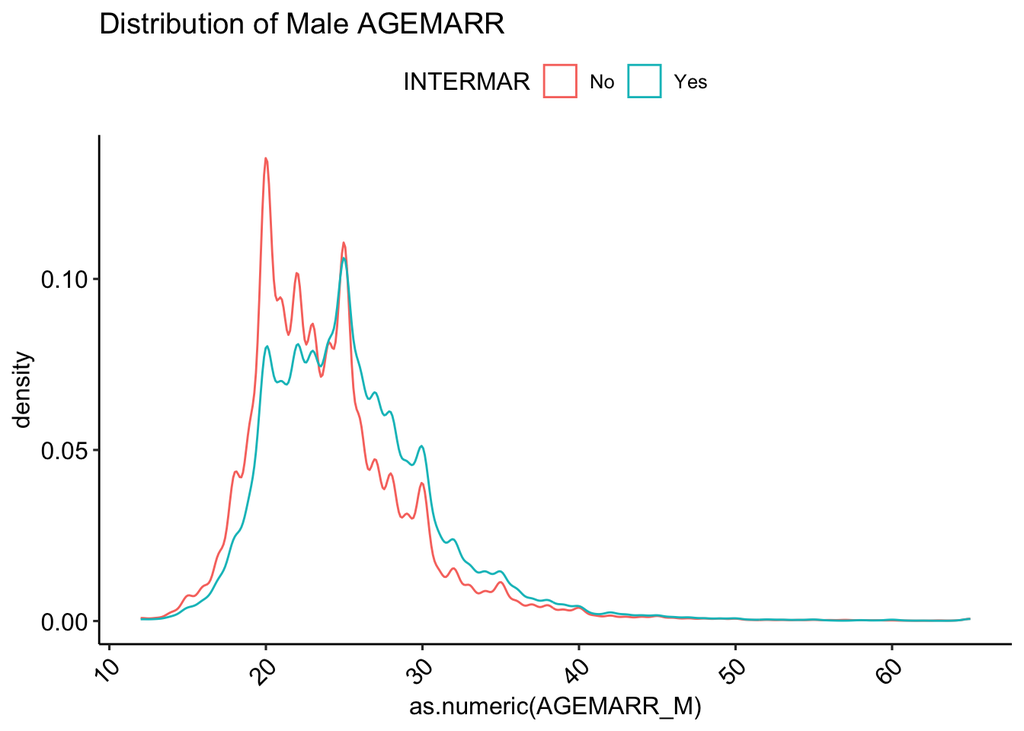

Calculations

*NOTE: I chose 20 as a cutoff for `URBAN`* *based on censuses where these values exist*

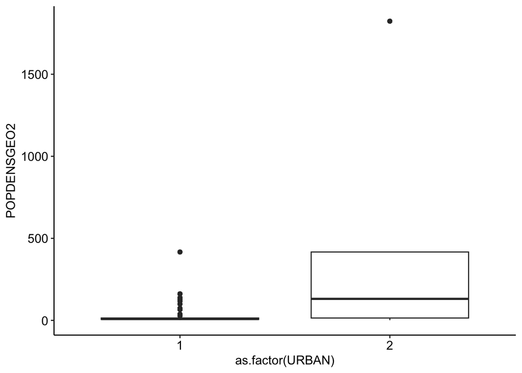

```
## RURAL Five-Number Summary (from 1990 and 2000): 1.37 6.23 11.62 16.39 2476.15
```

```
## URBAN Five-Number Summary (from 1990 and 2000): 1.37 26.23 347.25 1823.62 2476.15
```

Subsetting data

```r
by_province <- married_joined %>%
  group_by(PROVINCE_M, INTERMAR) %>%
  summarise(count = n()) %>%
  mutate(relative_frequency = count / sum(count)) %>%
  filter(INTERMAR == "Yes") %>%
  ungroup()
by_district <- married_joined %>%
  group_by(DISTRICT_M, INTERMAR) %>%
  summarise(count = n()) %>%
  mutate(relative_frequency = count / sum(count)) %>%
  filter(INTERMAR == "Yes") %>%
  ungroup()
by_year <- married_joined %>%
  group_by(YRMAR, INTERMAR) %>%
  summarise(count = n()) %>%
  mutate(relative_frequency = count / sum(count)) %>%
  filter(INTERMAR == "Yes") %>%
  ungroup()
by_year_block <- married_joined %>%
  mutate(YEAR_BLOCK = cut(YRMAR, breaks = seq(1941, 2011, by = 5),
                          right = FALSE,
                          labels = paste(seq(1941, 2006, by = 5),
                                         seq(1945, 2010, by = 5), sep = "-"))) %>%
  group_by(YEAR_BLOCK, INTERMAR) %>%
  summarise(count = n()) %>%
  mutate(relative_frequency = count / sum(count)) %>%
  filter(INTERMAR == "Yes") %>%
  ungroup()
by_year_block_urban <- married_joined %>%
  mutate(YEAR_BLOCK = cut(YRMAR, breaks = seq(1941, 2011, by = 5),
                          right = FALSE,
                          labels = paste(seq(1941, 2006, by = 5),
                                         seq(1945, 2010, by = 5), sep = "-"))) %>%
  group_by(YEAR_BLOCK, INTERMAR, URBAN) %>%
  summarise(count = n()) %>%
  mutate(relative_frequency = count / sum(count)) %>%
  filter(INTERMAR == "Yes") %>%
  ungroup()
by_year_block_urban_subset <- married_joined %>%
  filter(FULL_RESIDE) %>%
  mutate(YEAR_BLOCK = cut(YRMAR, breaks = seq(1941, 2011, by = 5),
                          right = FALSE,
                          labels = paste(seq(1941, 2006, by = 5),
                                         seq(1945, 2010, by = 5), sep = "-"))) %>%
  group_by(YEAR_BLOCK, INTERMAR, URBAN) %>%
  summarise(count = n()) %>%
  mutate(relative_frequency = count / sum(count)) %>%
  filter(INTERMAR == "Yes") %>%
  ungroup()
```

visualization

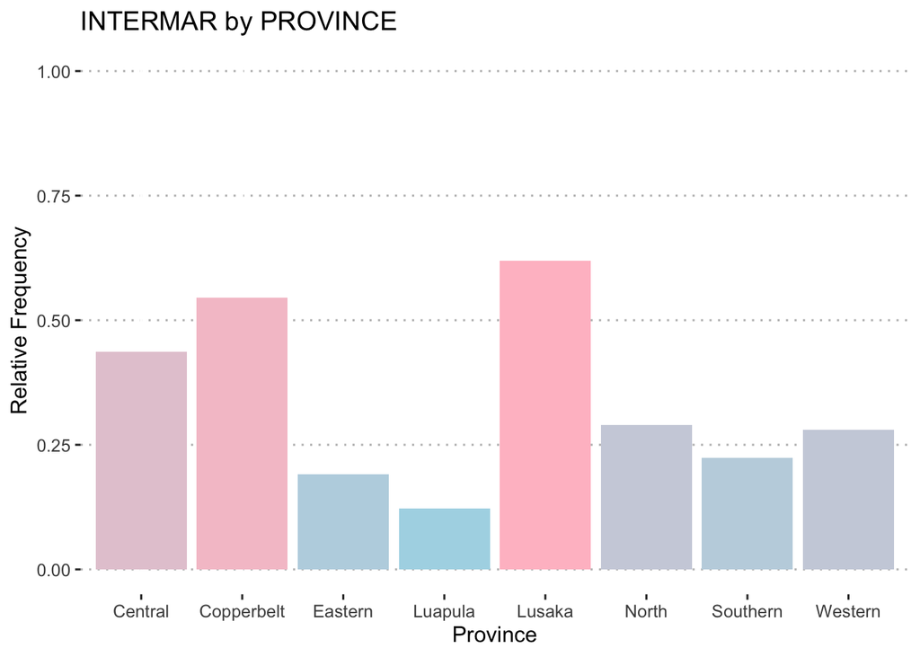

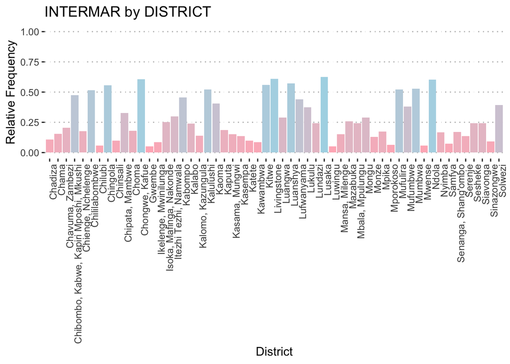

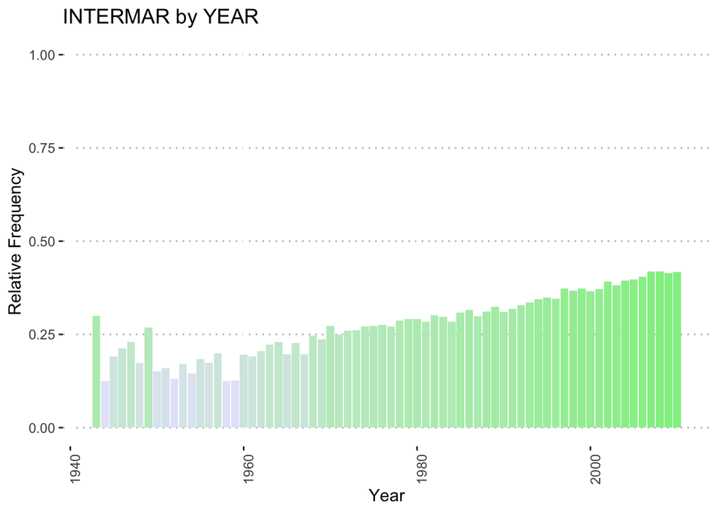

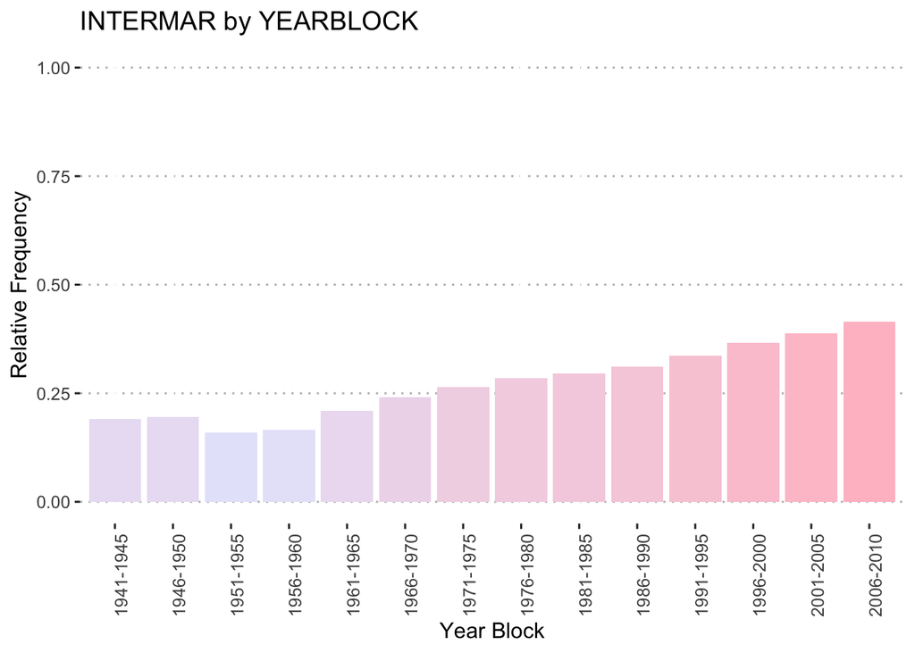

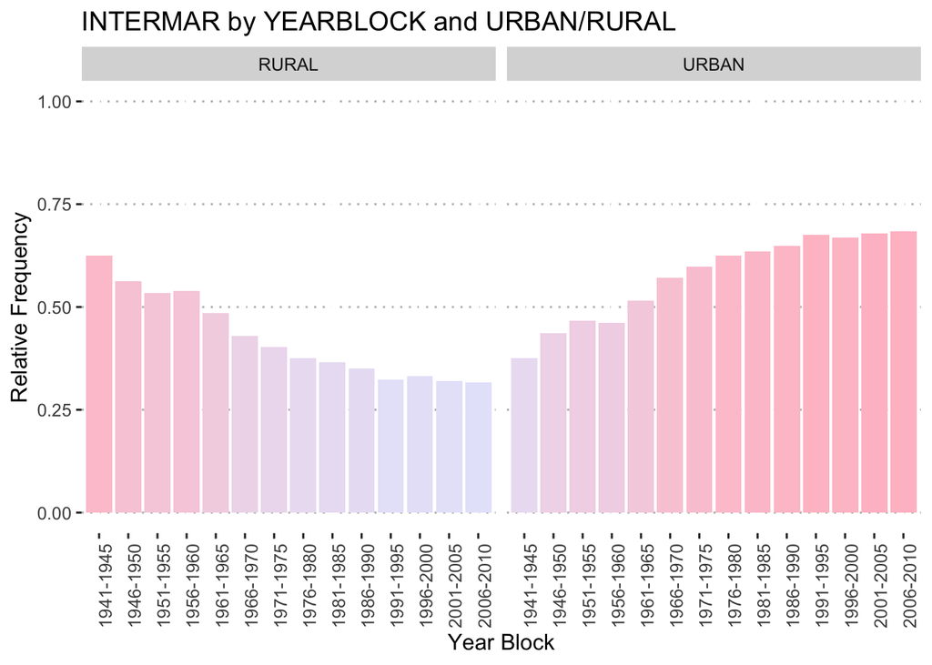

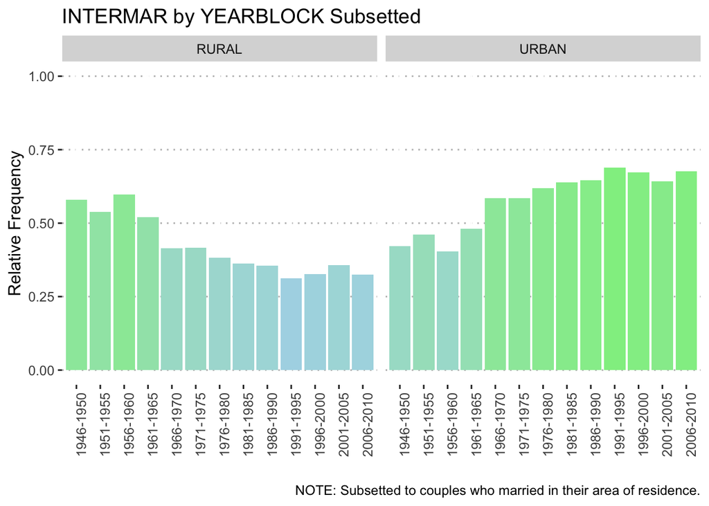

Full tables

```
## $`By year block/urban status (only those who married in current residence)`
## # A tibble: 26 × 3
##    YEAR_BLOCK URBAN relative_frequency
##    <fct>      <chr>              <dbl>
##  1 1946-1950  RURAL              0.579
##  2 1946-1950  URBAN              0.421
##  3 1951-1955  RURAL              0.538
##  4 1951-1955  URBAN              0.462
##  5 1956-1960  RURAL              0.597
##  6 1956-1960  URBAN              0.403
##  7 1961-1965  RURAL              0.520
##  8 1961-1965  URBAN              0.480
##  9 1966-1970  RURAL              0.414
## 10 1966-1970  URBAN              0.586
## # ℹ 16 more rows
```

ethnic distribution

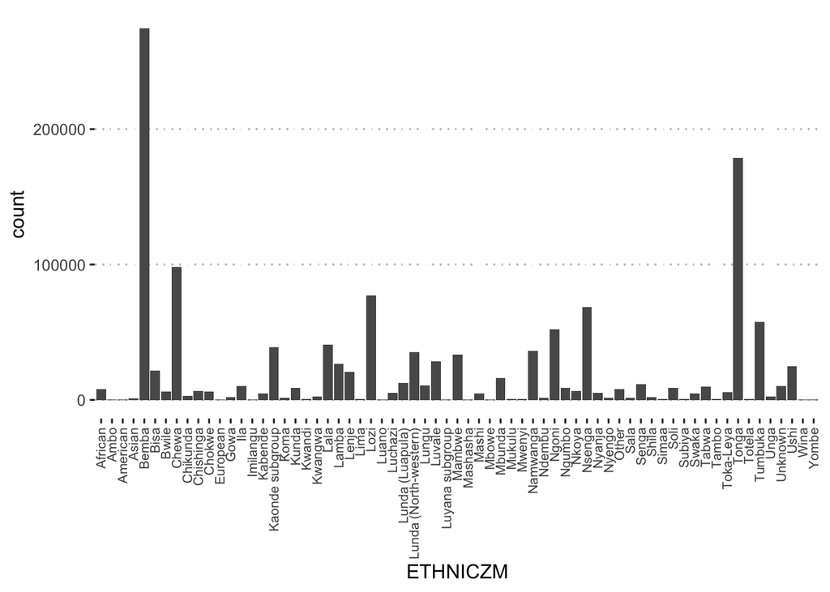

```r
ggplot(data_2010) + geom_bar(aes(x = ETHNICZM)) + theme_pubclean() +
  theme(axis.text.x = element_text(angle = 90, hjust = 1, vjust = 0.5, size = 8))
```

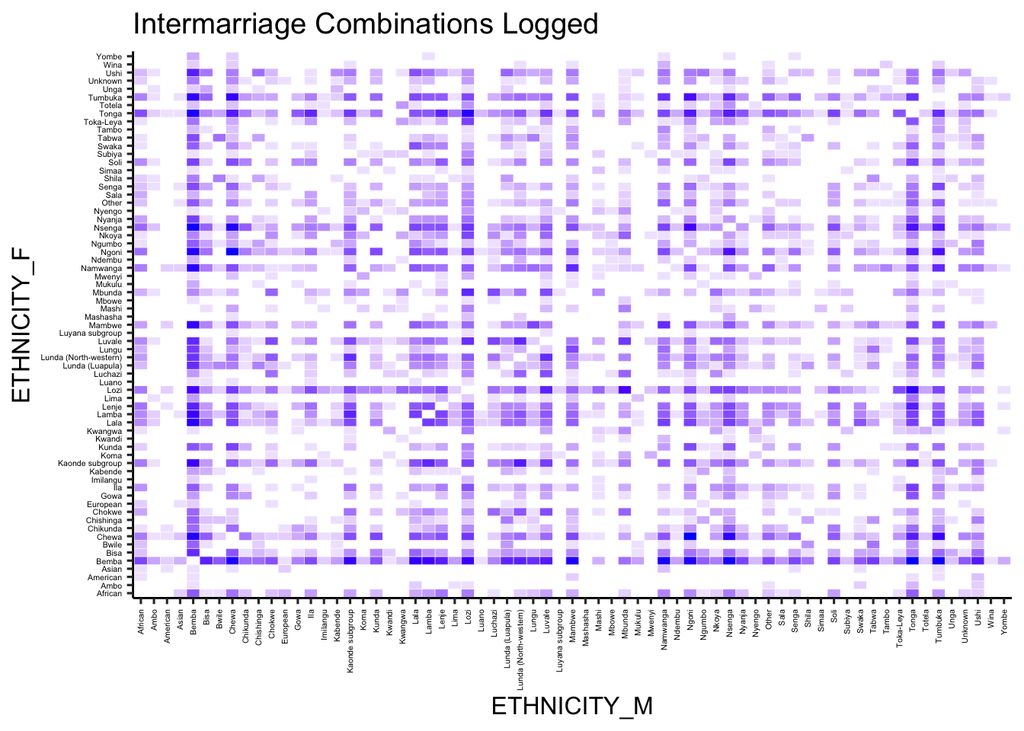

```r
combo_counts <- as.data.frame(table(married_joined$ETHNICZM_M, married_joined$ETHNICZM_F))
colnames(combo_counts) <- c("ethnicity_m", "ethnicity_f", "count")
combo_counts <- combo_counts %>% filter(ethnicity_m != ethnicity_f)

ggplot(combo_counts, aes(x = ethnicity_m, y = ethnicity_f)) +
  geom_tile(aes(fill = log(count+1)), color = "white") +
  scale_fill_gradient(low = "white", high = "blue") +
  theme_minimal() +
  labs(title = "Intermarriage Combinations Logged",
       x = "ETHNICITY_M",
       y = "ETHNICITY_F",
       fill = "Count") +
  theme_pubr() +
  theme(legend.position = "none") +
  theme(axis.text.x = element_text(angle = 90, hjust = 1, size = 4, vjust = 0.5),
        axis.text.y = element_text(angle = 0, hjust = 1, size = 4, vjust = 0.5))
```

```r
#nrow(combo_counts)
#print(arrange(combo_counts, desc(combo_counts$count)))
tbl <- as.data.frame(table(married_joined$ETHNICZM_M, married_joined$ETHNICZM_F)) %>% arrange(desc(Freq))
tbl <- as.data.frame(pivot_wider(tbl, names_from = Var2, values_from = Freq))
rownames(tbl) <- tbl$Var1
tbl %>% select(-Var1) %>% print(n = 67, width = 67, na.print = "")
```

```
##                       Bemba Tonga Chewa Lozi Nsenga Tumbuka Lala
## Bemba                 24689   761   653  369    829     580  635
## Tonga                   867 15092   261  562    326     162  112
## Chewa                   721   266  8373  124    695     535  102
## Lozi                    470   607   134 5223    145      89   48
## Nsenga                  787   261   602  116   5123     203  110
## Tumbuka                 825   177   475   98    276    4228   90
## Lala                    548    67    80   35     96      85 3296
## Ngoni                   696   269   894   98    366     343  104
## Namwanga                778    92    64   49    102     172  116
## Lunda (North-western)   240    61    35   66     31      35   36
## Mambwe                  714    79    91   41     82      78   46
## Kaonde subgroup         523   133    77   94     83      57   86
## Ushi                    272    30    20    9     28      20   66
## Bisa                    229    16    51   11     42      43   57
## Lamba                   412    58    36   37     65      57  123
## Luvale                  263   137    36  226     53      30   28
## Senga                    94    14    41    9     10      54   11
## Lenje                   256   238    75   80     72      53   72
## Lunda (Luapula)         217    20    19   10     18      22   34
## Lungu                   172     3     3    3      5      20    4
## Tabwa                   127     6     3    1      2       1    8
## Mbunda                   31    24     7  361      9       2    0
## Ngumbo                   50     3     0    3      6       7    5
## Chishinga                33     3     3    3      2       6    3
## Bwile                    57     7     2    2      1       0    0
## Kunda                    66    27    99   17     55      40   20
## Kabende                   9     3     2    4      2       2    6
## African                  91    78    23   23     36      19   15
## Ila                      83   209    27   80     23      20    4
## Mashi                     5    10     1   41      3       1    0
## Toka-Leya                23    64    11   81      5       5    4
## Other                    91    67    42   18     47      54   13
## Soli                    108   105    55   33     80      22   21
## Nkoya                    21    25     9   79     11       3    5
## Chokwe                   70     9     2   30      7       7    5
## Unga                      3     2     0    0      0       0    2
## Unknown                  57    23    17   12     13      14   10
## Nyanja                   98    65    11   37      9      12   23
## Swaka                    59    34     6    4      6       7   63
```

[output cut: 761 more lines]

```
## European                  0    0     0
## Simaa                     0    0     0
## Subiya                    0    0     0
## Mwenyi                    0    0     0
## Lima                      0    1     0
## Tambo                     0    0     0
## American                  0    0     0
## Luano                     0    0     0
## Imilangu                  0    0     0
## Wina                      0    0     0
## Luyana subgroup           0    0     0
## Ambo                      0    5     0
## Yombe                     3    0     0
## Mashasha                  0    0     0
## Mbowe                     0    0     5
```